# GUSła

Aleksandra Kulczycka & Stanisław Frelik

2024-06-04

# Wstęp

Teoria próbkowania stanowi jeden z istotnych fundamentów rzetelnego i skutecznego praktykowania statystyki. W szczególności, optymalna alokacja próbki w modelu ‘z warstwami’ stanowi podstawowy, a zarazem zaskakująco skomplikowany problem metodologii próbkowania. W tej pracy rozważymy problem minimalizacji wariancji $\pi$-estymatora za pomocą algorytmu symulowanego wyżarzania. Rozważymy dwa modele próbkowania w problemie z warstawmi - jednopoziomowe próbkowanie warstwowe oraz próbkowanie dwupoziomowe gdy ‘nadpopulacja’ również posiada warstwy.

# Opis metodologii

Interesujący nas problem postanowiliśmy zaprezentować na przykładzie.

Rozważmy pewną populację szkół przyporządkowanych do województw. Oczywiście zakładamy, że województwa, w sensie zbiorów szkół, są rozłączne, niepuste i stanowią pokrycie populacji szkół. W tym modelu o województwach będziemy mówili właśnie jako o warstwach, natomiast alokacją nazwiemy dowolny, możliwy wybór szkół. Przez możliwy mamy na myśli to, że liczba szkół w województwie, przy danej populacji, jest ustalona a co za tym idzie, otrzymujemy naturalne ograniczenia na wielkość alokacji w danej warstwie. Ponadto zakładamy, że mamy dane współczynniki wariancji dla każdej z warstw.

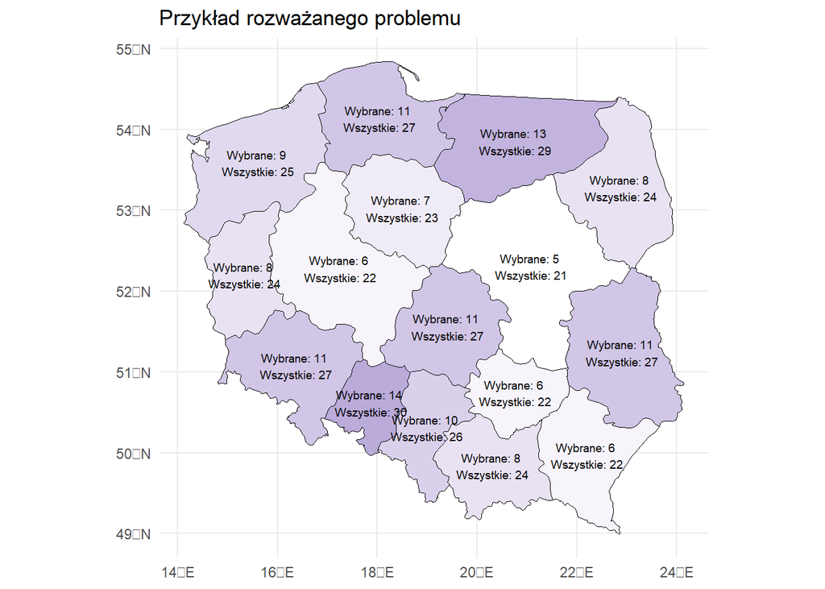

Opisany model stanowi przykład jednopoziomowego próbkowania warstwowego. Dalej rozważymy (dobrze znany z literatury) $\pi$-estymator całkowitej (lub średniej) wartości interesującej nas cechy charakteryzującej tę populację. Przy rozważanej metodologii ów estymator jest nieobciążony. Chcielibyśmy zatem minimalizować jego wariancję w celu uzyskania optymalnej alokacji. Nietrudno zauważyć, że już przy stosunkowo małej (jak na potrzeby rzeczywistych zastosowań) populacji szkół problem ten staje się zbyt skomplikowany obliczeniowo dla standardowych metod optymalizacji. W kolejnych rozdziałach pokażemy jak wykorzystać algorytm symulowanego wyżarzania do rozwiązania tego problemu.

Zgoła bardziej skomplikowana sytuacja występuje, gdy rozważymy model próbkowania dwustopniowego z warstwami. Wróćmy do przykładu z województwami i szkołami. Załóżmy ponadto, że w każdej szkole mamy pewną (ustaloną) liczbę uczniów, których cecha jest przedmiotem naszego badania (którą chcemy estymować w optymalny sposób). Wówczas alokacja będzie polegała na wyborze (na potrzeby tej pracy ustalonej) całkowitej liczby szkół z poszczególnych województw (pamiętając o naturalnych ograniczeniach górnych i dolnych) oraz wyborze pewnej liczby uczniów z każdej szkoły. Oczywiście na liczbę uczniów również występują naturalne ograniczenia - nie chcielibyśmy do próbki włączyć więcej uczniów niż faktycznie uczęszcza do konkretnej szkoły. Ponadto cała (dwustopniowa) populacja jest określona przez znane współczynniki wariancji (dla warstw i poszczególnych szkół). Pozostaje jeszcze określenie wielkości drugiego poziomu alokacji, czyli liczby uczniów. W tym celu konstruujemy estymator liczby uczniów, która powinna odpowiadać pierwszemu poziomowi alokacji (w szczególności liczba wybranych uczniów zależy od wyboru liczby szkół w województwach). Oczywiście, znalezienie optymalnej alokacji (minimalizacja wariancji $\pi$-estymatora) dla próbkowania dwustopniowego stanowi znaczące wyzwanie, zarówno teoretyczne jak i praktyczne. Ponownie wykorzystamy, odpowiednio zmodyfkiowany, algorytm symulowanego wyżarzania.

Precyzyjne sformułowanie powyższych problemów optymalizacji oraz zastosowanie algorytmu symulowanego wyżarzania przedstawimy w kolejnych rozdziałach.

# Inspiracje, literatura

Naszą główną motywacją były dwie prace traktujące o problemie optymalnej alokacji w przypadku populacji ‘z warstwami’:

- [1] ‘Recursive Neyman algorithm for optimum sample allocation under box constraints on sample sizes in strata’ (J. Wesołowski, R. Wieczorkowski, W. Wójciak)
- [2] ‘Fixed precision optimal allocation in two-stage sampling’ (W. Niemiro, J. Wesołowski)

Przedstawione w nich matematyczne sformułowania interesujących nas problemów, ich teoretyczne rozwiązania oraz zaimplementowane algorytmy zdecydowanie ułatwiły nam pracę. Warto w tym miejscu zaznaczyć, iż pełne zagadnienie optymalnej alokacji (to znaczy z pełnymi ograniczeniami) w przypadku próbkowania dwustopniowego z warstwami nie zostało do tej pory rozwikłane. Stąd tym bardziej istotna staje się druga część naszej pracy, w której rozważamy właśnie to zagadnienie.

Informacje na temat algorytmu symulowanego wyżarzania czerpaliśmy z książki:

- [3] ‘Finite Markov Chains and Algorithmic Applications’ (O. Häggström)

# Próbkowanie jednostopniowe

W tym rozdziale zaprezentujemy jak wykorzystać algorytm symulowanego wyżarzania do znalezienia optymalnej alokacji w przypadku próbkowania jednostopniowego z warstwami - czyli do minimalizacji wariancji $\pi$-estymatora.

## Sformułowanie matematyczne

Interesujący nas problem zapiszemy w języku optymalizacji. Przyjmijmy oznaczenia:

- $H$ - liczba warstw charakteryzująca rozważaną populację
- $A_h$ - znane współczynniki wariancji w każdej z warstw ($h = 1, \ldots, H$)
- $x_h$ - liczba elementów z warstwy $h$ wybrana do próbki
- $M_h$ - całkowita liczba elementów w $h$-tej warstwie
- $m_h$ - dolne ograniczenie na liczbę elementów wybranych do próbki z $h$-tej warstwy
- $n$ - ustalona wielkość próbki

Wówczas na podstawie [1] wiemy, że wariancja $\pi$-estymatora wyraża się wzorem:

$\sum_{h=1}^H \frac{A_h^2}{x_h}$

Natomiast problem optymalizacji możemy zapisać jako:

$\min_{\mathbf{x = (x_h)_{h=1}^H}} \sum_{h=1}^H \frac{A_h^2}{x_h}$

$\text{przy ograniczeniach:}\ \sum_{h=1}^H x_h = n\quad \text{oraz}\quad \forall_h\ m_h \leq x_h \leq M_h$

## Rozwiązanie algorytmiczne

Zauważmy od razu, że choć zadanie optymalizacji zdefiniowane w poprzedniej części nie jest całkowitoliczbowe, dla uproszczenia rozważymy jedynie alokacje całkowitoliczbowe. Nasz przykład dobrze ilustruje tę kwestię - trudno byłoby wybrać dwie i pół szkoły z danego województwa.

Nasza implementacja algorytmu symulowanego wyżarzania jest w tym przypadku w pełni klasyczna. Sąsiedztwo alokacji definiujemy poprzez jednostkową różnicę na dwóch pozycjach w próbce (czyli sąsiadem będzie alokacja, w której z jednego województwa zabraliśmy jedną szkołę, a w innym dodaliśmy (też jedną)). Stąd wykorzystując tak zdefiniowane sąsiedztwo i indukowany przez nie łańcuch Metropolisa oraz rozkład Boltzmanna [3] otrzymujemy teoretyczny zarys algorytmu symulowanego wyżarzania. Jego uproszczony schemat przezntujemy poniżej:

1. Załóżmy, że mamy pewną alokację $\xi$.
2. Losujemy jednostajne ze zbioru $\{1, \ldots, H\}$ dwa indeksy, przy czym chcemy, by były one istotnie różne.
3. Na podstawie tych indeksów proponujemy kolejny krok algorytmu, to znaczy (o ile pozwalają na to ograniczenia dolne i górne) z jednej pozycji alokacji zabieramy jeden element, a na drugiej dodajemy. Oznaczmy tę propozycję przez $\tilde{\xi}$
4. Obliczamy funkcję celu, czyli wariancję (oznaczenie: $f$) i następnie:
1. z prawdopodobieństwem $\min\Big[\exp\left( \frac{f(\xi)-f(\tilde{\xi})}{T}\right), 1\Big]$ akceptujemy zaproponowany krok
2. z prawdopodobieństwem $1-\min\Big[\exp\left( \frac{f(\xi)-f(\tilde{\xi})}{T}\right), 1\Big]$ zostajemy w bieżącej alokacji

```r
library(stratallo)  # biblioteka dot. RNABOX
library(ggplot2)

inverse_num <- function(x) {
  return(1/x)
}

target <- function(x, A) {
  return(sum(1/x * A^2))  # Funkcja obliczająca wartość funkcji celu dla danego wektora x i A
}

gen_prop_box <- function(x) {
  indices <- sample(seq_along(x), 2, replace = FALSE)  # Losowanie dwóch różnych indeksów z x
  index_move_1 <- indices[1]
  index_move_2 <- indices[2]

  if (index_move_1 != index_move_2) {
    if (x[index_move_1] >= m[index_move_1] & x[index_move_2] > m[index_move_2]) {
      if (x[index_move_1] < M[index_move_1] & x[index_move_2] <= M[index_move_2]) {
        x_prop <- x
        x_prop[index_move_1] <- x_prop[index_move_1] + 1
        x_prop[index_move_2] <- x_prop[index_move_2] - 1
      } else {
        x_prop <- x
      }
    } else {
      x_prop <- x
    }
  } else {
    x_prop <- x
  }
  return(x_prop)  # Zwracamy nowy wektor propozycji
}

sim_anal_box <- function(x, N, S, m, M, n, T_schedule, N_schedule) {
  A <- N * S
  target_values <- numeric(sum(N_schedule))  # Inicjalizacja wektora dla wartości docelowych
  solutions <- list()
  index <- 1
  temperature_change_points <- cumsum(N_schedule)  # Punkty zmiany temperatury

  initial_target <- target(x, A)

  for (i in 1:length(N_schedule)) {
    T_temp <- T_schedule[i]  # Aktualna temperatura
    for (j in 1:N_schedule[i]) {
      x_prop <- gen_prop_box(x)  # Wygenerowanie nowej propozycji
      transit_func <- exp(-(target(x, A) - target(x_prop, A)) / T_temp)  # Funkcja przejścia
      prob_stay <- min(1, transit_func)  # Prawdopodobieństwo pozostania w obecnym stanie
      prob_move <- 1 - prob_stay  # Prawdopodobieństwo zmiany stanu
      coin_flip <- runif(1)
      if (coin_flip <= prob_stay) {
        x <- x  # Pozostaj w obecnym stanie
      } else {
        x <- x_prop  # Przejdź do nowej propozycji
      }
      target_values[index] <- target(x, A)
      solutions[[index]] <- x
      index <- index + 1
    }
  }

  return(list(solution = x, target_values = target_values, solutions = solutions, temperature_change_points = temperature_change_points))  # Zwraca ostateczne rozwiązanie, wartości docelowe, rozwiązania i punkty zmiany temperatury
}
```

## Przykłady

Przykład 1

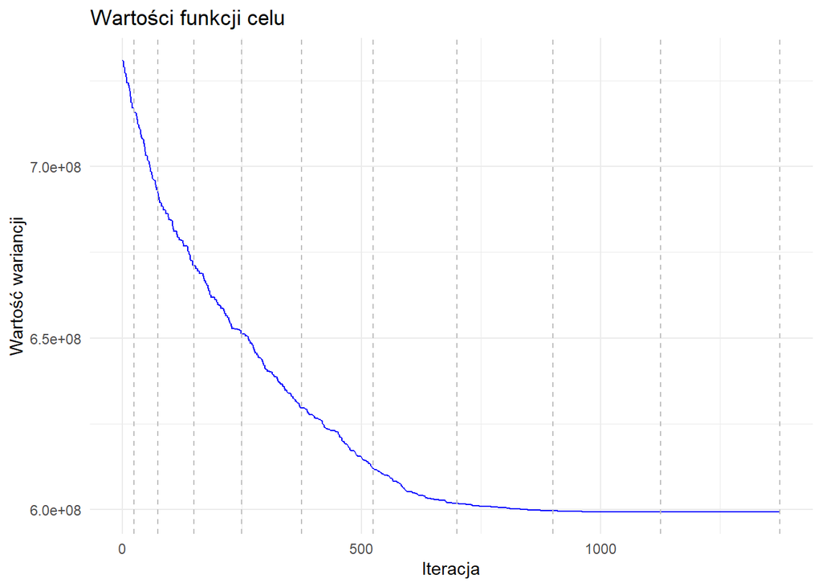

```r
N <- c(3000, 4000, 5000, 2000) # Rozmiary warstw
S <- c(48, 79, 76, 16) # Odchylenia standardowe zmiennej badanej w warstwach
A <- N * S
m <- c(100, 90, 500, 50) # Dolne ograniczenia na wielkości próby w warstwach
M <- c(300, 400, 800, 90) # Górne ograniczenia na wielkości próby w warstwach
n <- 1284  # Ustalona wielkość próby
T_schedule <- 10:1/100 # Harmonogram wyżarzania (temperatura)
N_schedule <- (1:length(T_schedule)) * 25 # Harmonogram wyżarzania (czas)
x <- c(100, 300, 800, 84) # Zainicjalizowana alokacja


sim_data <- sim_anal_box(x, N, S, m, M, n, T_schedule, N_schedule)

target_df <- data.frame(iteration = 1:length(sim_data$target_values), target_value = sim_data$target_values)

solutions_df <- do.call(rbind, lapply(1:length(sim_data$solutions), function(i) {
  data.frame(iteration = i, strata = 1:length(sim_data$solutions[[i]]), value = sim_data$solutions[[i]])
}))

target_plot <- ggplot(target_df, aes(x = iteration, y = target_value)) +
  geom_line(color = "blue") +
  geom_vline(xintercept = sim_data$temperature_change_points, linetype = "dashed", color = "grey") +
  labs(x = "Iteracja", y = "Wartość wariancji", title = "Wartości funkcji celu") +
  theme_minimal()


solution_plot <- ggplot(solutions_df, aes(x = iteration, y = value, group = strata, color = as.factor(strata))) +
  geom_line() +
  labs(x = "Iteracja", y = "Rozmiar próbki", color = "Warstwa", title = "Trajektoria dążąca do optymalnej alokacji") +
  theme_minimal()



target_plot
```

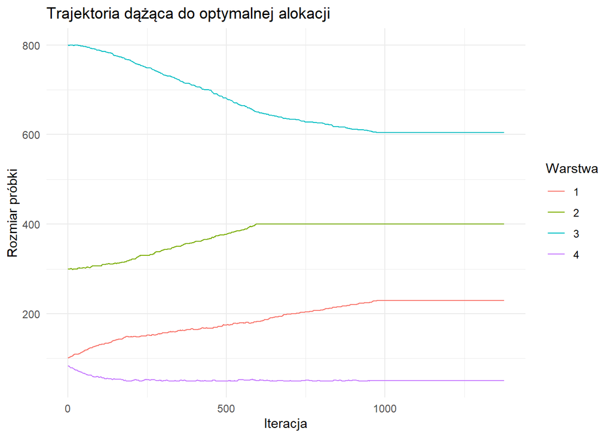

```r
solution_plot
```

```r
# Finalne rozwiązanie
final_solution <- sim_data$solution

# Optymalna wartość z algorytmu RNABox
optimal_value <- opt(n = n, A = A, m = m, M = M)

# Wariancja
final_variance <- sim_data$target_values[length(sim_data$target_values)]

# Wydrukowanie wyników
print("Finalne rozwiązanie:")
```

```
## [1] "Finalne rozwiązanie:"
```

```r
print(final_solution)
```

```
## [1] 229 400 604  51
```

```r
# Optymalna wartość z algorytmu RNABox
print("Optymalna wartość z algorytmu RNABox:")
```

```
## [1] "Optymalna wartość z algorytmu RNABox:"
```

```r
print(optimal_value)
```

```
## [1] 228.9496 400.0000 604.1727  50.8777
```

```r
# Wariancja
print("Wariancja:")
```

```
## [1] "Wariancja:"
```

```r
print(final_variance)
```

```
## [1] 599341497
```

Przykład 2

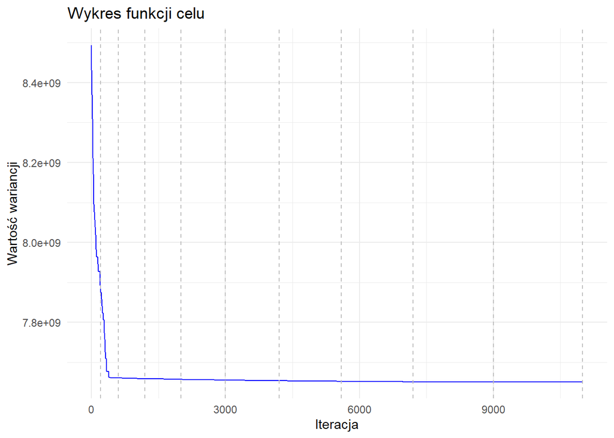

```r
url <- "https://github.com/wwojciech/stratallo/raw/main/data/pop10_mM.rda"
download.file(url, destfile = "pop10_mM.rda")
load("pop10_mM.rda")

df <- pop10_mM
N <- df[, 1]
S <- df[,2]
m <- df[,3]
M <- df[,4]
n <- 3000
x <- c(60, 90, 75, 65, 400, 400, 500, 605, 205, 600)
A <- N * S

T_schedule <- 10:1/100 # Annealing schedule (temperature)
N_schedule <- (1:length(T_schedule)) * 200 # Annealing schedule (time)

sim_data <- sim_anal_box(x, N, S, m, M, n, T_schedule, N_schedule)

target_df <- data.frame(iteration = 1:length(sim_data$target_values), target_value = sim_data$target_values)

solutions_df <- do.call(rbind, lapply(1:length(sim_data$solutions), function(i) {
  data.frame(iteration = i, strata = 1:length(sim_data$solutions[[i]]), value = sim_data$solutions[[i]])
}))

ggplot(target_df, aes(x = iteration, y = target_value)) +
  geom_line(color = "blue") +
  geom_vline(xintercept = sim_data$temperature_change_points, linetype = "dashed", color = "grey") +
  labs(x = "Iteracja", y = "Wartość wariancji", title = "Wykres funkcji celu") + # Dodanie tytułu
  theme_minimal()
```

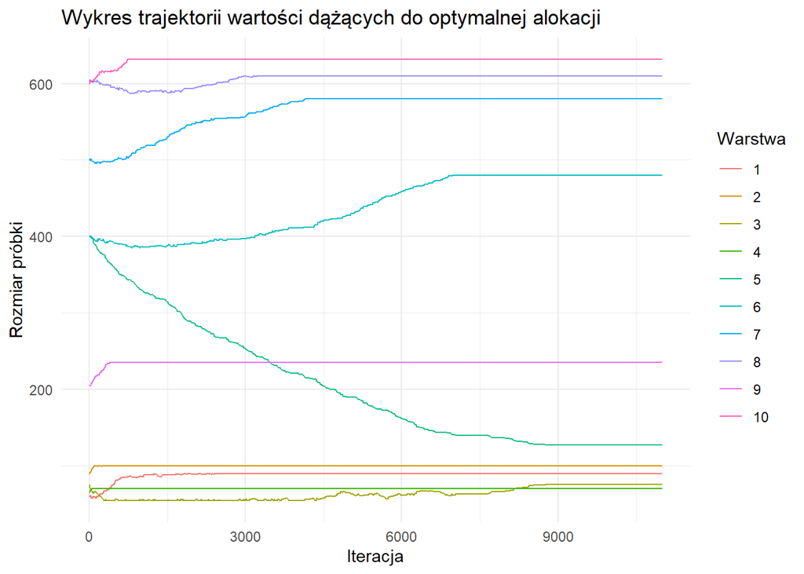

```r
ggplot(solutions_df, aes(x = iteration, y = value, group = strata, color = as.factor(strata))) +
  geom_line() +
  labs(x = "Iteracja", y = "Rozmiar próbki", color = "Warstwa", title = "Wykres trajektorii wartości dążących do optymalnej alokacji") + # Dodanie tytułu
  theme_minimal()
```

```r
# Finalne rozwiązanie
final_solution <- sim_data$solution

# Optymalna wartość z algorytmu RNABox
optimal_value <- opt(n = n, A = A, m = m, M = M)

# Wariancja
final_variance <- sim_data$target_values[length(sim_data$target_values)]

# Wydrukowanie wyników
print("Finalne rozwiązanie:")
```

```
## [1] "Finalne rozwiązanie:"
```

```r
print(final_solution)
```

```
##  [1]  90 100  76  70 127 480 580 610 235 632
```

```r
# Optymalna wartość z algorytmu RNABox
print("Optymalna wartość z algorytmu RNABox:")
```

```
## [1] "Optymalna wartość z algorytmu RNABox:"
```

```r
print(optimal_value)
```

```
##  [1]  90.000 100.000  76.125  70.000 126.875 480.000 580.000 610.000 235.000
## [10] 632.000
```

```r
# Wariancja
print("Wariancja:")
```

```
## [1] "Wariancja:"
```

```r
print(final_variance)
```

```
## [1] 7650905275
```

Przykład 3

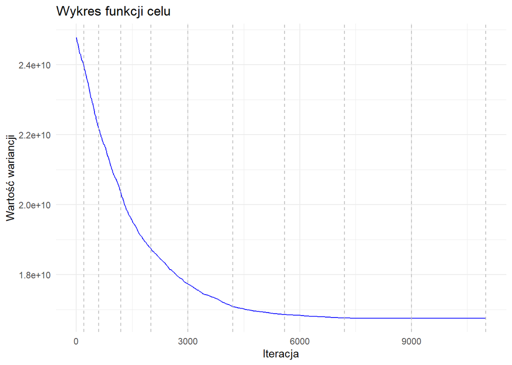

```r
set.seed(123) # Ustawienie ziarna losowości dla powtarzalności

N <- sample(2000:10000, 20, replace = TRUE)
S <- runif(20, 30, 100)
A <- N * S
m <- sample(10:100, 20, replace = TRUE)
M <- m + sample(100:500, 20, replace = TRUE)
T_schedule <- 10:1/100
N_schedule <- (1:length(T_schedule)) * 200
x <- m + round(runif(20, 0, 1) * (M - m))
n <- sum(x)

sim_data <- sim_anal_box(x, N, S, m, M, n, T_schedule, N_schedule)

target_df <- data.frame(iteration = 1:length(sim_data$target_values), target_value = sim_data$target_values)

solutions_df <- do.call(rbind, lapply(1:length(sim_data$solutions), function(i) {
  data.frame(iteration = i, strata = 1:length(sim_data$solutions[[i]]), value = sim_data$solutions[[i]])
}))

ggplot(target_df, aes(x = iteration, y = target_value)) +
  geom_line(color = "blue") +
  geom_vline(xintercept = sim_data$temperature_change_points, linetype = "dashed", color = "grey") +
  labs(x = "Iteracja", y = "Wartość wariancji", title = "Wykres funkcji celu") + # Dodanie tytułu
  theme_minimal()
```

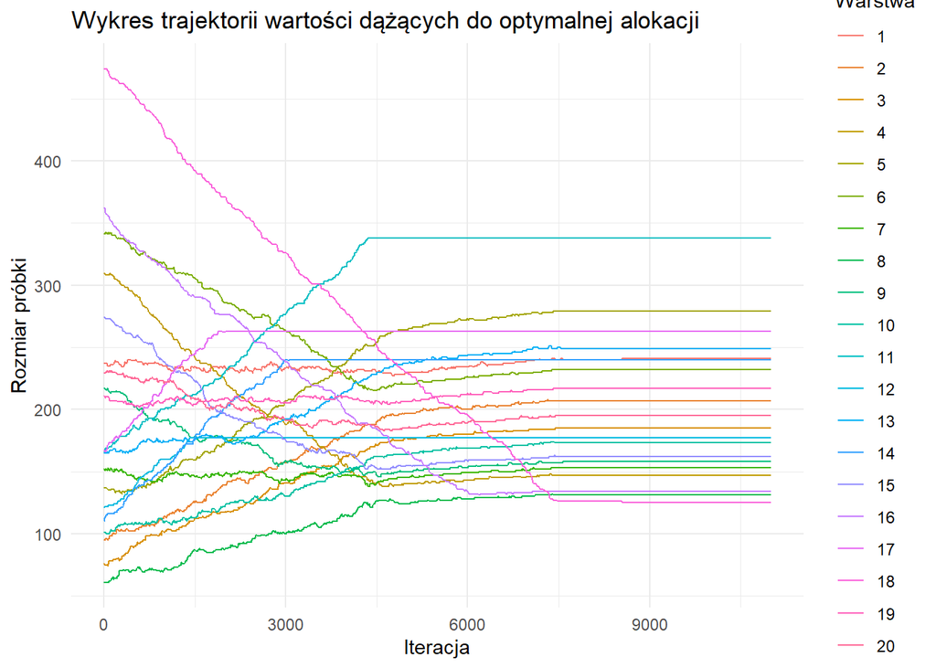

```r
ggplot(solutions_df, aes(x = iteration, y = value, group = strata, color = as.factor(strata))) +
  geom_line() +
  labs(x = "Iteracja", y = "Rozmiar próbki", color = "Warstwa", title = "Wykres trajektorii wartości dążących do optymalnej alokacji") + # Dodanie tytułu
  theme_minimal()
```

```r
# Finalne rozwiązanie
final_solution <- sim_data$solution

# Optymalna wartość z algorytmu RNABox
optimal_value <- opt(n = n, A = A, m = m, M = M)

# Wariancja
final_variance <- sim_data$target_values[length(sim_data$target_values)]

# Wydrukowanie wyników
print("Finalne rozwiązanie:")
```

```
## [1] "Finalne rozwiązanie:"
```

```r
print(final_solution)
```

```
##  [1] 241 207 185 147 279 232 153 131 158 173 338 177 249 240 162 134 263 125 217
## [20] 195
```

```r
# Optymalna wartość z algorytmu RNABox
print("Optymalna wartość z algorytmu RNABox:")
```

```
## [1] "Optymalna wartość z algorytmu RNABox:"
```

```r
print(optimal_value)
```

```
##  [1] 240.5749 206.8694 184.8025 146.9558 278.9715 231.8640 152.8143 131.3986
##  [9] 157.6540 173.0306 338.0000 177.0000 249.2896 240.0000 162.1079 134.4315
## [17] 263.0000 125.4748 217.0554 194.7053
```

```r
# Wariancja
print("Wariancja:")
```

```
## [1] "Wariancja:"
```

```r
print(final_variance)
```

```
## [1] 16756536924
```

# Próbkowanie dwustopniowe

Po rozgrzewce jaką było próbkowanie jednostopniowe przechodzimy do zdecydowanie bardziej skomplikowanego problemu - próbkowania dwustopniowego z warstwami. Zaznaczmy tu, że tylko jeden ‘poziom populacji’ w naszym zadaniu będzie podzielony na warstwy. Dokładniej będzie to zawsze ‘wyższy’ poziom. Przywołując po raz kolejny nasz przykład, chcemy wybrać pewną liczbę uczniów ze szkół, które są przyporządkowane do województw.

## Sformułowanie matematyczne

Wprowadźmy notację potrzebną do sformułowania zadania optymalizacji. Z racji próbkowania dwustopniowego dalej nazywamy próbki z pierwszego stopnia (np. szkoły) jednostkami pierwotnymi (JP), natomiast próbki z drugiego stopnia (np. uczniów) jednostami wtórnymi (JW).

- $V = W_1 + \ldots + W_H$ - populacja podzielona na warstwy
- $\#(W_h) = M_h$ - liczba JP w $h$-tej warstwie ($h = 1, \ldots, H$)
- $m_h$ - liczba JP wybranych do próbki z $h$-tej warstwy
- $U_{h, j}$ - $j$-ta JP z $h$-tej warstwy
- $\#(U_{h, j}) = N_{h, j}$ - liczba JW w $j$-tej JP z $h$-tej warstwy
- $n_{h, j}$ - liczba JW wybranych do próbki z $j$-tej JP z $h$-tej warstwy (pod warunkiem wybrania $U_{h, j}$ do próbki)
- $N_h = \sum_{j \in W_h} N_{h, j}$

Niech $\hat{t}$ będzie standardowym $\pi$-estymatorem (estymatorem Horvitza-Thompsona, [2]) całkowitej (lub średniej) wartości pewnej cechy $t$. Z [2] wiemy, że jego wariancja dana jest wzorem:

$D^2(\hat{t}) = \sum_{h=1}^H \left( \frac{1}{m_h} - \frac{1}{M_h} \right) M_h^2 D_h^2 + \sum_{h=1}^H \frac{M_h}{m_h} \sum_{j=1}^{M_h} \left( \frac{1}{n_{h,j}} - \frac{1}{N_{h, j}} \right) N_{h, j}^2 S_{h, j}^2$

gdzie:

$t_{h,j} = \sum_{u \in U_{h,j}} y_{h,j,u}, \quad \bar{y}_{h,j} = \frac{t_{h,j}}{N_{h,j}} \quad \text{oraz} \quad \bar{t}_h = \frac{\sum_{j=1}^{M_h} t_{h,j}}{M_h}$

$S^2_{h,j} = \frac{1}{N_{h,j} - 1} \sum_{u \in U_{h,j}} \left( y_{h,j,u} - \bar{y}_{h,j} \right)^2,\quad D^2_h = \frac{1}{M_h - 1} \sum_{j=1}^{M_h} \left( t_{h,j} - \bar{t}_h \right)^2$

Zatem naszym zadaniem jest minimalizacja $D^2(\hat{t})$ jako funkcji $m_h$ i $n_{h, j}$. Ponadto zakładamy, że liczność próbki pierwotnej (czyli liczba JP w próbce) jest ustalona, to znaczy: $\sum_{h=1}^H m_h = m$. Natomiast w celu ustalenia liczności próbki wtórnej (liczby JW w próbce) rozważamy estymator jej oczekiwanej wielkości postaci:

$\sum_{h=1}^H \frac{m_h}{M_h} \sum_{j=1}^{M_h} n_{h, j} = n$

W szczególności widzimy, że $n$ istotnie zależy od wyboru JP. Będzie to miało znaczenie dla implementacji algorytmu symulowanego wyżarzania.

## Rozwiązanie algorytmiczne

Podstawowym pytaniem stawianym nam przez algorytm symulowanego wyżarzania jest sposób określenia ‘sąsiedztwa’ pomiędzy alokacjami. Nie jest on w tym przypadku tak oczywisty, jak dla próbkowania jednostopniowego. Co więcej, właśnie ta decyzja będzie miała największy wpływ na szybkość i skuteczność jego implementacji. Nasz pomysł prezentuje się następująco:

Określamy sąsiedztwo dla JP i JW w standardowy sposób, analogicznie jak w przypadku próbkowania jednostopniowego. Powracając do przykładu, powiemy, że dwie alokacje na poziomie szkół są sąsiadami jeśli różnią się na dwóch pozycjach o jedną szkołę (przy zachowaniu ich całkowitej liczby). Celowo nie mówimy tu nic o wyborze uczniów dla tych alokacji. Podobnie na poziomie uczniów, powiemy, że dwie alokacje są sąsiadami jeśli różnią się na dwóch pozycjach o jednego ucznia (oczywiście przy ustalonym wyborze szkół a co za tym idzie, przy stałej oczekiwanej liczbie uczniów w próbce). Natomiast zdefiniowanie sąsiedztwa w przypadku, w którym nie ustalamy jednego z poziomów wydaje się mało realne - pojawia się tu wiele problemów, przede wszystkim związanych z ograniczeniami górnymi. Okazuje się jednak, że tak zadane sąsiedztwo jest wystarczające. Poniżej opisujemy schematyczny proces generowania i wyboru kolejnego kroku:

Zanim będziemy gotowi uruchomić nasz algorytm potrzebujemy wczytać potrzebne nam funkcje oraz wygenerować przykładową populację dla problemu próbkowania dwustopniowego z warstwami.

#### *Funkcja celu, funkcje generujące propozycję*

```r
set.seed(1337)

inverse_num <- function(x){
  return(1/x)
}

# target function - D^2(t_hat)

target <- function(V_sample, M_PSU, strat_var, df_picked_students_number, df, school_var, df_picked_schools){
    temp1 <- sum((inverse_num(V_sample) - inverse_num(M_PSU)) * M_PSU^2 * strat_var)
    temp2 <- 0
    for(i in 1:length(M_PSU)){
      temp3 <- 0
      for(j in 1:max(M_PSU)){
        if(df_picked_schools[i, j] != 0){
        temp3 <- temp3 + (inverse_num(df_picked_students_number[i, j]) -
                            inverse_num(df[i, j]) * df[i, j]^2 * school_var[i, j])
        }else{temp3 <- temp3}
      }
      temp2 <- temp2 + temp3 * M_PSU[i]/V_sample[i]
    }
    return(temp1 + temp2)
}

# proposition generators:

gen_prop_box_stratified_PSU <- function(V_sample, m_PSU, M_PSU){
  index_move_PSU_1 <- ceiling(runif(1, min=0, max=length(V_sample)))
  index_move_PSU_2 <- ceiling(runif(1, min=0, max=length(V_sample)))
  if(index_move_PSU_1 == index_move_PSU_2){
    return(V_sample)
  }
  if(V_sample[index_move_PSU_1] >= m_PSU[index_move_PSU_1] &
     V_sample[index_move_PSU_1] < M_PSU[index_move_PSU_1] &
     V_sample[index_move_PSU_2] > m_PSU[index_move_PSU_2] &
     V_sample[index_move_PSU_2] <= M_PSU[index_move_PSU_2]){

    V_prop <- V_sample
    V_prop[index_move_PSU_1] <- V_prop[index_move_PSU_1] + 1
    V_prop[index_move_PSU_2] <- V_prop[index_move_PSU_2] - 1

  }else{
    return(V_sample)
  }
  return(V_prop)
}

gen_prop_box_stratified_SSU <- function(m_school_bound, df, df_picked_students_number, df_picked_schools){
  index_move_SSU_1 <- ceiling(runif(1, min=0, max=m_school_bound))
  index_move_SSU_2 <- ceiling(runif(1, min=0, max=m_school_bound))
  if(index_move_SSU_1 == index_move_SSU_2){
    return(df_picked_students_number)
  }
  indexes_of_picked_PSU <- unname(which(df_picked_schools == 1, arr.ind = T))
  index_move_SSU_1 <- indexes_of_picked_PSU[index_move_SSU_1,]
  index_move_SSU_2 <- indexes_of_picked_PSU[index_move_SSU_2,]
  if(df_picked_students_number[index_move_SSU_1[1], index_move_SSU_1[2]] <
     df[index_move_SSU_1[1], index_move_SSU_1[2]] &
     df_picked_students_number[index_move_SSU_1[1], index_move_SSU_1[2]] >= 0 &
     df_picked_students_number[index_move_SSU_2[1], index_move_SSU_2[2]] <=
     df[index_move_SSU_2[1], index_move_SSU_2[2]] &
     df_picked_students_number[index_move_SSU_2[1], index_move_SSU_2[2]] > 1){
    df_picked_students_number_prop <- df_picked_students_number
    df_picked_students_number_prop[index_move_SSU_1[1], index_move_SSU_1[2]] <-
      df_picked_students_number_prop[index_move_SSU_1[1], index_move_SSU_1[2]] + 1
    df_picked_students_number_prop[index_move_SSU_2[1], index_move_SSU_2[2]] <-
      df_picked_students_number_prop[index_move_SSU_2[1], index_move_SSU_2[2]] - 1
  }else{
    return(df_picked_students_number)
  }
  return(df_picked_students_number_prop)
}
```

Dalej generujemy przykładową populację, która składa się z pięciu warstw:

#### *Generator przykładu, obliczamy jego parametry*

```r
# Box constrains:
M_PSU <- c(35, 40, 50, 70, 150) # (V) PSU upper bounds
m_PSU <- c(1, 1, 1, 1, 1) # PSU lower bounds
M_SSU <- 50 # Max number of students in a school
stud_param <- 25 # Max value of a student parameter (e. g. height, used to estimate pop. variance)
m_school_bound <- 200 # num of schools
```

```r
# Generate school matrix:

df <- matrix(0, nrow = length(M_PSU), ncol = max(M_PSU))
for(i in 1:length(M_PSU)){
  v <- sample.int(M_SSU, M_PSU[i], replace = T) + 1 # (!!!) schools need to have at least 2 students
  df[i, 1:M_PSU[i]] <- v
} # df[i, j] - number of 'students' in j'SSU from i'PSU

# Generate students parameters: (for the sake of D^2 & S^2)

df_t <- 0
n <- length(M_PSU) * max(M_PSU)
df_t <- as.list(numeric(n))
dim(df_t) <- c(length(M_PSU), max(M_PSU))

for(i in 1:length(M_PSU)){
  for(j in 1:max(M_PSU)){
    l <- df[i, j]
    if(l == 0){
      df_t[[i, j]] <- 0
    }else{
      u <- sample.int(stud_param, l, replace = T)
      df_t[[i, j]] <- u
    }
  }
} # df_t[[i, j]][u] - value of the interest parameter form the u-th student form j-th school from i-th discrict

# school totals: t_(h, j):
df_t_totals <- matrix(0, nrow = length(M_PSU), ncol = max(M_PSU))

for(i in 1:length(M_PSU)){
  for(j in 1:max(M_PSU)){
    df_t_totals[i, j] <- sum(df_t[[i, j]])
  }
}

# stratum average: t_dash:
strat_avg <- numeric(length(M_PSU))
for(i in 1:length(M_PSU)){
  strat_avg[i] <- sum(df_t_totals[i, ])/M_PSU[i]
}

# school average:
df_t_school_avg <- matrix(0, nrow = length(M_PSU), ncol = max(M_PSU))
for(i in 1:length(M_PSU)){
  for(j in 1:max(M_PSU)){
    if(length(df_t[[i, j]]) != 0){
      df_t_school_avg[i, j] <- df_t_totals[i, j] / length(df_t[[i, j]])
    }else{df_t_school_avg[i, j] <- 0}
  }
}

# stratum variance (D^2)_h:
strat_var <- numeric(length(M_PSU))
for(i in 1:length(M_PSU)){
  strat_var[i] <- sum((df_t_totals[i,]-strat_avg[i])^2)/(M_PSU[i]-1)
}

# school variance (S^2)_(h, j):
school_var <- matrix(0, nrow = length(M_PSU), ncol = max(M_PSU))
for(i in 1:length(M_PSU)){
  for(j in 1:max(M_PSU)){
    if(length(df_t[[i, j]]) != 1){
      school_var[i, j] <- sum((df_t[[i, j]]-df_t_school_avg[i, j])^2)/(length(df_t[[i, j]])-1)
    }else{school_var[i, j] <- 0}
  }
}
```

Potrzebujemy jeszcze startowej akolacji, której użyjemy do uruchomienia algorytmu symulowanego wyżarzania:

#### *Generator startowej alokacji*

```r
# generate school sample with size bounds:
V_sample <- numeric(length(M_PSU))
while(sum(V_sample) != m_school_bound){
  V_sample <- numeric(length(M_PSU))
  for(i in 1:length(M_PSU)){
    V_sample[i] <- sample.int(M_PSU[i], 1)
  }
  if(any(V_sample < m_PSU)){
    V_sample <- numeric(length(M_PSU))
  }
}
# pick speficic schools (indexes from df)
df_picked_schools <- matrix(0, nrow = length(M_PSU), ncol = max(M_PSU))
for(i in 1:length(M_PSU)){
  s <- sample.int(M_PSU[i], V_sample[i])
  for(j in 1:length(s)){
    df_picked_schools[i, s[j]] <- 1
  }
}

# generate student sample size (from df with respect to V_sample))
stud_sample_size <- 0
for(i in 1:length(M_PSU)){
  temp <- V_sample[i]/M_PSU[i]
  stud_sample_size <- stud_sample_size + temp * sum(df[i, ] * df_picked_schools[i, ])
}

# all students:
stud_all <- sum(df * df_picked_schools)

# generate student sample
df_picked_students_number <- df_picked_schools
for(i in 1:length(M_PSU)){
  for(j in 1:max(M_PSU)){
    df_picked_students_number[i, j] <- df_picked_students_number[i, j] *
      df[i, j] * stud_sample_size / stud_all
  }
}
# generate student matrix (small error):
for(i in 1:length(M_PSU)){
  for(j in 1:max(M_PSU)){
    if(df_picked_students_number[i, j] - floor(df_picked_students_number[i, j]) > 0.5){
      df_picked_students_number[i, j] <- ceiling(df_picked_students_number[i, j])
    }else{df_picked_students_number[i, j] <- floor(df_picked_students_number[i, j])}
  }
}
```

Mając już wygenerowaną populację i punkt startowy pozostaje wyłącznie postawienie schematu wyżarzania. Znalezienie jednak, w ogólności, schematu optymalnego wydaje się zgoła niemożliwe. Z pomocą licznych prób doszliśmy do schematu, który najczęściej dawał zadowalające wyniki, przy czym czasami istotnie zależały one od wygenerowanego punktu początkowego. Chcielibyśmy podsumować ten wybór stwierdzeniem, iż dla danej populacji znalezienie schematu optymalnego wydaje się być głównie kwestią czasu, czyli kwestią prób i błędów. Poniżej prezentujemy nasz wybór:

#### *Schemat wyżarzania*

```r
eps <- 1e-10 #for the sake of numeric stability (avoiding zero-division)
T_schedule <- 1:20*100000 # Annealing schedule (temperature)
N_schedule <- numeric(length(T_schedule)) + 20 # Annealing schedule (time)
N_schedule[1] <- N_schedule[1] + 500
N_schedule[2] <- N_schedule[2] + 300
N_schedule[3] <- N_schedule[3] + 200
N_schedule[4] <- N_schedule[4] + 100
```

#### *Implementacja*

```
## Uzyskana alokacja:
```

```
## 35 37 33 41 54
```

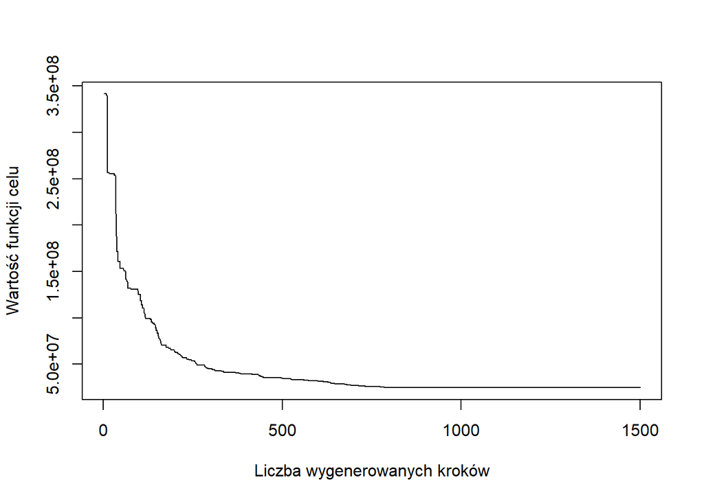

```r
# For plotting and assessments
temp_target_PSU_change <- list()
temp_target_SSU_change <- list()
temp_step_PSU <- list()
temp_step_SSU <- list()

# THE annealing:

for(i in 1:length(N_schedule)){
  T_temp <- T_schedule[i]
  for(j in 1:N_schedule[i]){
    V_prop <- gen_prop_box_stratified_PSU(V_sample, m_PSU, M_PSU)
    df_picked_schools_V_prop <- matrix(0, nrow = length(M_PSU), ncol = max(M_PSU))
    for(i in 1:length(M_PSU)){
      s <- sample.int(M_PSU[i], V_prop[i])
      for(j in 1:length(s)){
        df_picked_schools_V_prop[i, s[j]] <- 1
      }
    }
    stud_sample_size_V_prop <- 0
    for(i in 1:length(M_PSU)){
      temp <- V_prop[i]/M_PSU[i]
      stud_sample_size_V_prop <- stud_sample_size_V_prop + temp * sum(df[i, ] * df_picked_schools_V_prop[i, ])
    }
    stud_all_V_prop <- sum(df * df_picked_schools_V_prop)
    df_picked_students_number_V_prop <- df_picked_schools_V_prop
    for(i in 1:length(M_PSU)){
      for(j in 1:max(M_PSU)){
        df_picked_students_number_V_prop[i, j] <- df_picked_students_number_V_prop[i, j] *
          df[i, j] * stud_sample_size_V_prop / stud_all_V_prop
      }
    }
    for(i in 1:length(M_PSU)){
      for(j in 1:max(M_PSU)){
        if(df_picked_students_number_V_prop[i, j] - floor(df_picked_students_number_V_prop[i, j]) > 0.5){
          df_picked_students_number_V_prop[i, j] <- ceiling(df_picked_students_number_V_prop[i, j])
        }else{df_picked_students_number_V_prop[i, j] <- floor(df_picked_students_number_V_prop[i, j])}
      }
    }
    df_picked_students_number_prop <- gen_prop_box_stratified_SSU(m_school_bound, df,
                                                                  df_picked_students_number,
                                                                  df_picked_schools)
    transit_value_PSU <- exp((target(V_sample, M_PSU, strat_var,
                                     df_picked_students_number,
                                     df, school_var, df_picked_schools)-
                                target(V_prop, M_PSU, strat_var,
                                       df_picked_students_number_V_prop,
                                       df, school_var, df_picked_schools_V_prop))/T_temp)
    transit_value_SSU <- exp((target(V_sample, M_PSU, strat_var,
                                     df_picked_students_number,
                                     df, school_var, df_picked_schools)-
                                target(V_sample, M_PSU, strat_var,
                                       df_picked_students_number_prop,
                                       df, school_var, df_picked_schools))/T_temp)
    temp_target_PSU_change <- append(temp_target_PSU_change, target(V_sample, M_PSU, strat_var,
                                                                    df_picked_students_number,
                                                                    df, school_var, df_picked_schools))
    temp_target_SSU_change <- append(temp_target_SSU_change, target(V_sample, M_PSU, strat_var,
                                                                    df_picked_students_number,
                                                                    df, school_var, df_picked_schools))
    prob_move_PSU <- min(1, transit_value_PSU)
    prob_move_SSU <- min(1, transit_value_SSU)
    mass <- target(V_prop, M_PSU, strat_var,
                   df_picked_students_number_V_prop,
                   df, school_var, df_picked_schools_V_prop) +
      target(V_sample, M_PSU, strat_var,
             df_picked_students_number_prop,
             df, school_var, df_picked_schools)
    #print(V_sample)
    if(prob_move_PSU == 1 & prob_move_SSU == 1){
      coin_flip <- runif(1)
      if(target(V_prop, M_PSU, strat_var,
                df_picked_students_number_V_prop,
                df, school_var, df_picked_schools_V_prop)/mass > coin_flip){
        V_sample <- V_prop
        temp_step_PSU <- append(temp_step_PSU, length(which(unlist(temp_step_PSU) > 0)) + 1)
        temp_step_SSU <- append(temp_step_SSU, 0)
      }else{
        df_picked_students_number <- df_picked_students_number_prop
        temp_step_SSU <- append(temp_step_SSU, length(which(unlist(temp_step_SSU) > 0)) + 1)
        temp_step_PSU <- append(temp_step_PSU, 0)
      }
    }
    if(prob_move_PSU == 1 & prob_move_SSU < 1){
      V_sample <- V_prop
      temp_step_PSU <- append(temp_step_PSU, length(which(unlist(temp_step_PSU) > 0)) + 1)
      temp_step_SSU <- append(temp_step_SSU, 0)
    }
    if(prob_move_PSU < 1 & prob_move_SSU == 1){
      df_picked_students_number <- df_picked_students_number_prop
      temp_step_SSU <- append(temp_step_SSU, length(which(unlist(temp_step_SSU) > 0)) + 1)
      temp_step_PSU <- append(temp_step_PSU, 0)
    }
    if(prob_move_PSU < 1 & prob_move_SSU < 1){
      if(prob_move_PSU < eps & prob_move_SSU < eps){
        V_sample <- V_sample
        df_picked_students_number <- df_picked_students_number
        temp_step_SSU <- append(temp_step_SSU, -50)
        temp_step_PSU <- append(temp_step_PSU, -50)
      }
      if(prob_move_PSU > prob_move_SSU){
        coin_flip <- runif(1)
        if(coin_flip < prob_move_PSU){
          V_sample <- V_prop
          temp_step_PSU <- append(temp_step_PSU, length(which(unlist(temp_step_PSU) > 0)) + 1)
          temp_step_SSU <- append(temp_step_SSU, 0)
        }else{
          V_sample <- V_sample
          df_picked_students_number <- df_picked_students_number
          temp_step_SSU <- append(temp_step_SSU, -50)
          temp_step_PSU <- append(temp_step_PSU, -50)
        }
      }
      if(prob_move_SSU > prob_move_PSU){
        coin_flip <- runif(1)
        if(coin_flip < prob_move_SSU){
          df_picked_students_number <- df_picked_students_number_prop
          temp_step_SSU <- append(temp_step_SSU, length(which(unlist(temp_step_SSU) > 0)) + 1)
          temp_step_PSU <- append(temp_step_PSU, 0)
        }else{
          V_sample <- V_sample
          df_picked_students_number <- df_picked_students_number
          temp_step_SSU <- append(temp_step_SSU, -50)
          temp_step_PSU <- append(temp_step_PSU, -50)
        }
      }
      if(prob_move_PSU == prob_move_SSU){
        V_sample <- V_sample
        df_picked_students_number <- df_picked_students_number
        temp_step_SSU <- append(temp_step_SSU, -50)
        temp_step_PSU <- append(temp_step_PSU, -50)
      }
    }
  }
}
```

## Porównania

Pomimo tego, iż na podstawie powyższego wykresu moglibyśmy wnioskować, że nasz algorytm faktycznie zbiegł do (jakiegoś) rozwiązania, to chcielibyśmy móc je z czymś porównać. Oczywiście dobrą praktyką byłoby wykonanie symulowanego wyżarzania wielokrotnie w celu uzyskania statystycznego oglądu na sytuację. My jednak zestawimy otrzymany wynik z teoretycznym, uzyskanym w pracy [2]. Co warto pamiętać, w tej pracy dowód optymalności alkoacji został przeprowadzony w przypadku bez (naturalnych) ograniczeń górnych. Niemniej my optymalizujemy po istotnie mniejszym zbiorze, więc jeżeli nasz wynik będzie stostunkowo zbliżony do teoretycznego, to będzie to świadczyło, że jest on ‘całkiem dobry’. W celu tego porównania zaprezentujemy formalnie optymalną alokację występującą w [2] (czyli bez ograniczeń górnych), wyliczymy ją na podstawie wygenerowanej wcześniej populacji i zestawimy z alokacją otrzymaną poprzez algorytm symulowanego wyżarzania.

Pod warunkiem $\gamma_h = M_h D^2_h - \sum_{j=1}^{M_h} N_{h,j} S^2_{h,j} > 0$ optymalna alokacja przyjmuje postać:

$m_h = \frac{\sqrt{M_h \gamma_h}}{\sum_{k=1}^H \sqrt{M_k \gamma_k}}m$

$n_{h, j} = n \frac{M_h}{m_h} \cdot \frac{N_{h, j} S_{h, j}}{\sum_{k=1}^H \sum_{l=1}^{M_k} N_{k,l} S_{k,l}}$

Natomiast minimalna wariancja wyraża się wzorem:

$D_{opt}^2(\hat{t}) = \frac{1}{m} \left( \sum_{h=1}^H \sqrt{M_h \gamma_h} \right)^2 + \frac{1}{n} \left( \sum_{h=1}^H \sum_{j=1}^{M_h} N_{h, j} S_{h, j} \right)^2 - \sum_{h=1}^H M_h D_h^2$

#### *Porównania*

```r
gamma <- M_PSU * strat_var
for(i in 1:length(gamma)){
  gamma[i] <- gamma[i] - sum(df[i,]*school_var[i,])
}
# optimal alloc:
opt_PSU <- m_school_bound * sqrt(M_PSU * gamma)/sum(sqrt(M_PSU * gamma))
opt_SSU <- matrix(0, nrow = length(M_PSU), ncol = max(M_PSU))
temp <- 0
for(i in 1:length(M_PSU)){
  temp <- temp + sum(df[i, ] * sqrt(school_var[i, ]))
}
for(i in 1:length(M_PSU)){
  for(j in 1:max(M_PSU)){
    opt_SSU[i, j] <- stud_sample_size * (M_PSU[i]/opt_PSU[i]) * df[i, j] * sqrt(school_var[i, j])/temp
  }
}
# optimal variance:
opt_var <- sum(sqrt(M_PSU * gamma))^2/m_school_bound + (temp)^2/stud_sample_size - sum(M_PSU * strat_var)
cat("Optymalna alokacja na poziomie JP:", opt_PSU)
```

```
## Optymalna alokacja na poziomie JP: 37.505 38.9149 34.7059 42.87965 45.99456
```

```r
cat("Uzyskana alokacja na poziome JP:", V_sample)
```

```
## Uzyskana alokacja na poziome JP: 35 37 33 41 54
```

```r
cat("Optymalna wariancja:", opt_var)
```

```
## Optymalna wariancja: 24704649
```

```r
cat("Uzyskana wariancja:", unlist(temp_target_PSU_change)[length(unlist(temp_target_PSU_change))])
```

```
## Uzyskana wariancja: 24726833
```

```r
cat("Błąd względny: ", abs(unlist(temp_target_PSU_change)[length(unlist(temp_target_PSU_change))]-opt_var)/opt_var)
```

```
## Błąd względny:  0.000897938
```

# Podsumowanie

W tej pracy skupiliśmy się na opisaniu dwóch modeli próbkowania warstwowego oraz zastosowaliśmy do obu zagadnień algorytm symulowanego wyżarzania w celu znalezienia optymalnej alokacji. Pomimo licznych (nawet bardzo licznych) potknięć, szczególnie w części drugiej, udało nam się uzyskać względnie zadowalające wyniki - zarówno pod względem jakości jak i efektywności rozwiązań. Niemniej rozważane problemy dalej pozostawiają wiele pracy. Teoria próbkowania okazała się (dość zaskakująco) być niezwykle bogata, zarówno pod względem głębokości i szerokości podejmowanych aspektów matematycznych jak i wymagań informatycznych, oraz wyjątkowo satysfakcjonująca do ‘pogłówkowania nad’. Jesteśmy przekonani, że nasze rozwiązanie algorytmiczne problemu drugiego można na wielu płaszczyznach istotnie ulepszyć. Wartym uwagi wydają się nie tylko potencjalnie inne modyfikacje samej części ‘wyżarzającej’ czy jej parametry, ale również podpierająca je konstrukcja ‘danych’.

Podczas tego typu projektów kluczowym wydaje się być odpowiednie podejście do zadania. Aby ciężka praca była faktycznie satysfakcjonująca trzeba zbudować z rozważanym problemem pewną emocjonalną więź - inaczej są to tylko litery i cyfry, które na koniec nie mają większego znaczenia. Życzymy sobie oraz czytelnikowi właśnie tego w kolejnych wyzwaniach.

Dziękujemy za uwagę!